# C03

Previous:Lecture 2_(C Basics) Next: Lecture 4 (Decision Making)

Lecture 3 Arithmatic Operators & Data Types

#### CSCI218 Engineering Programming (by Kebin Xu)

1. Numerical data type
   - integer and float
   - Arithmetic Operators
   - **Integer division and modulo**
   - **Data type conversions**
2. **Data Representation in computer**
   - Number representation and conversion
   - interger representation
   - character representation(ASCII and Unicode)
3. **Data types & Placeholders**
   - Arduino C Data Types
   - Standard C Data Types
   - size of data
   - printf() formatting placeholder
4. **Other datatypes**
   - boolean
   - string

back to top

1 Numerical datatype

1.1 integer and float

- **integers** (can be positive or negative whole number)
  - e.g. 50, -390
  - int value = -5;
  - unsigned int num = 10;
  - long int bigValue = - 49322032;
  - unsigned long biggish = 59302012;
- **floating-point**: numbers that can have fractional parts are represented as floating point (or float) values. (zb2.7 Floating-point numbers (double)
  - has decimal point, even the decimal part is 0, eg. 3.0
  - float voltage = 3.3;
  - double temp = 79.5;

**Question**: Why do we need two number types?

**Ans**:

- Values that represent counts can’t be fractional (you can’t have 3 ½ quarters). Integer variables are typically used for values that are counted, like 42 cars, 10 pizzas, or -95 days.
- Most mathematical algorithms are very efficient with integers
- Floating-point variables are typically used for measurements, like 98.6 degrees, 0.00001 meters, or -55.667 degrees. The float type stores only an approximation to the real number being represented!

back to top

1.2 Arithmetic Operators

Following table shows all the arithmetic operators supported by C language. Assume variable A holds 10 and variable B holds 20, then:

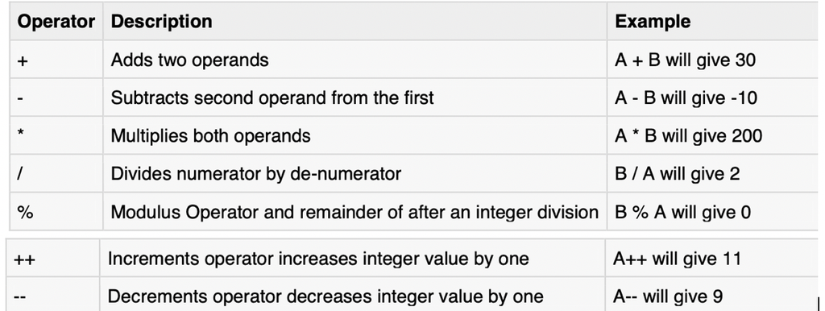

**Notes**: the `-` operator is also for negation, as in -x + y, or x + -y.

```c
//Example 1-1
#include <stdio.h>
int main()
{
    float a = 2.0;
    float b = 0.5, c ;
    printf("a = %f, b = %f\n", a, b);



    c = a + b;
    printf("c = a + b - Value of c is %f\n", c );
    c = a - b;
    printf("c = a - b - Value of c is %f\n", c );
    c = a * b;
    printf("c = a * b - Value of c is %f\n", c );
    c = a / b;
    printf("c = a / b - Value of c is %f\n", c );

    //c = a % b;
    printf("You cannot do modular %% for floating point numbers.\n" );

    a++;
    b--;
    printf("after a++, b--: a = %f, b = %f\n", a, b);
    ++a;
    --b;
    printf("after ++a, --b: a = %f, b = %f\n", a, b);

    //FYI:
    c = a++; // c = a; then a++
    printf("c = a++ : Value of c is %f, a is %f \n", c,a );
    c = a--;
    printf("c = a-- : Value of c is %f, a is %f \n", c,a );

    c = ++a; //  a++, then assign to c
    printf("c = ++a : Value of c is %f, a is %f \n", c, a );
    c = --a;
    printf("c = --a : Value of c is %f, a is %f \n", c,a );


    return 0;
}
```

```
a = 2.000000, b = 0.500000
c = a + b - Value of c is 2.500000
c = a - b - Value of c is 1.500000
c = a * b - Value of c is 1.000000
c = a / b - Value of c is 4.000000
You cannot do modular % for floating point numbers.
after a++, b--: a = 3.000000, b = -0.500000
after ++a, --b: a = 4.000000, b = -1.500000
c = a++ : Value of c is 4.000000, a is 5.000000
c = a-- : Value of c is 5.000000, a is 4.000000
c = ++a : Value of c is 5.000000, a is 5.000000
c = --a : Value of c is 4.000000, a is 4.000000
```

back to top

1.3 Integer division and modulo

see zb2.11 Integer division and modulo

- When **both** operands of **$/$** are `integers`, the operator performs **integer division**, which does not generate any fraction.
- The modulo operator (**%**) evaluates the remainder of the division of `two integer operands`.

### integer division / and modulus (remainder) %

In integer division and modulus, the dividend (11 in the example) is divided by the divisor (4) into an integer quotient (2) and a remainder (3). The integer quotient operation is referred to as integer division, (so 11 / 4 is 2 ) and the integer remainder operation is the modulus (so 11 % 4 is 3)

[figure not shown]

Modulo(%)

The modulo operator (%) evaluates the remainder of the division of **two integer operands**. Ex: 23 % 10 is 3.

- 24 % 10 is 4. Reason: 24 / 10 is 2 with remainder 4.
- 50 % 50 is 0. Reason: 50 / 50 is 1 with remainder 0.
- 1 % 2 is 1. Reason: 1 / 2 is 0 with remainder 1.
- 10 % `4.0` is `not valid`. **"Remainder" only makes sense for integer operands**

Division (/)

### Floating-point division

The $/$ operator performs **floating-point division** if at least one operand is a floating-point type.

[figure not shown]

- If `both operands` of / are `integers`, the operator performs **integer division**: No fractional part is generated. Thus 10 / 4 is 2, not 2.5. And 3 / 4 is 0, not 0.75.
- Programmers may forget integer division, causing strange logic errors. (1/2) *b* h is always (0) *b* h or 0. And c *(9/5) + 32 is always c* (1) + 32.
- The same applies for integer variables. No fraction is generated for y = w / x if w and x are int type, even if y is a floating-point type.
- If `at least one operand` of / is a `floating-point` type, then **floating-point division** occurs. So if int w = 10 and double x = 4.0, then w / x is 2.5.

```c
//Example 1-2
#include <stdio.h>
int main()
{
    int y;
    float z;

    //integer division
    y = 10 / 4;
    z = 10 / 4; //assign an integer to a float

    //We use format specifier %d for integer, %f for float
    printf("10/4 is %d, y is %d , z is %f\n", 10 / 4, y, z);

    //float division: 10/4.0 will produce a float
    y = 10 / 4.0; //assign a float to int will discard the decimal part
    z = 10 / 4.0;

    printf("10/4.0 is %f, y is %d , z is %f\n", 10 / 4.0, y, z);

    //can we do this?
    //printf("y is %f\n", y);
    return 0;
}
```

```
10/4 is 2, y is 2 , z is 2.000000
10/4.0 is 2.500000, y is 2 , z is 2.500000
```

Division: Divide by 0

- For integer division, the second operand of / or % must never be 0, because division by 0 is mathematically undefined. A **divide-by-zero error** occurs at runtime if a divisor is 0, causing a program to terminate
- any number $/0$ or %0 is undefined, cause program to terminate

```c
//Example 1-3
#include <stdio.h>
int main(){

    printf("23 %% 3 / 4 = %d\n", 23 % 3 / 4);
    printf("23 %% (3 / 4) will cause ERROR, why?\n");
    printf("23 / 3 %% 4 = %d\n", 23 / 3 % 4);
    printf("23 / 3 / 4 = %d\n", 23 / 3 / 4);
    printf("23.0 / 3 / 4 = %f (using %%f)\n", 23.0 / 3 / 4);

    return 0;
}
```

```
23 % 3 / 4 = 0
23 % (3 / 4) will cause ERROR, why?
23 / 3 % 4 = 3
23 / 3 / 4 = 1
23.0 / 3 / 4 = 1.916667 (using %f)
```

back to top

1.4 Type conversions

see zb2.12 Type conversions

Implicit conversion

A type conversion is a conversion of one data type to another, such as an int to a float. The compiler automatically performs several common conversions between int and float types, such automatic conversion known as **implicit conversion**.

- For an arithmetic operator like + or *, if either operand is a float, the other is automatically converted to float, and then a floating-point operation is performed.
- For assignments, the right side type is converted to the left side type.
  - int-to-float conversion is straightforward: 25 becomes 25.0.
  - float-to-int conversion just drops the fraction: 4.9 becomes 4.

#### see see [zyBook2.12](https://learn.zybooks.com/zybook/COFCCSCI218XuFall2022/chapter/2/section/12) for examples

A calculation sometimes must mix integer and floating-point numbers. For example, given that about 50.4% of human births are males, then `0.504 * numBirths` calculates the number of expected males in numBirths births. If numBirths is an int variable (int because the number of births is countable), then the expression combines a floating-point and integer.

```c
//Example 1-4a
#include <stdio.h>
int main() {

    int numBirths = 10;
    float maleBirthRate = 0.54;


    //%d does not work for float (maleBirthRate * numBirths is a float)
    printf("maleBirths = %f", maleBirthRate * numBirths);


    return 0;
}
```

```
maleBirths = 5.400000
```

```c
//Example 1-4b

#include <stdio.h>
int main() {

    int maleBirths;
    float numBirths = 10.0;
    float maleBirthRate = 0.54; //we expected to see 6 males
    maleBirths = maleBirthRate * numBirths;

    // this works! because maleBirths is an integer, how about the value?
    printf("maleBirths = %d", maleBirths);

    return 0;
}
```

```
maleBirths = 5
```

```c
//Example 1-4c
//Using math function ceil() to round the results
#include <stdio.h>
#include <math.h>
int main() {

    int maleBirths, numBirths = 10;
    float maleBirthRate = 0.504;
    maleBirths = ceil(maleBirthRate * numBirths);

    printf("maleBirths = %d", maleBirths);

    return 0;
}
```

[output not shown]

Type casting

A programmer sometimes needs to explicitly convert an item's type.

- Ex: If a program needs a floating-point result from dividing two integers, (see floating division 9/4) then at least one of the integers needs to be converted to float so floating-point division is performed (9/4.0 or 9.0/4). Otherwise, integer division is performed, evaluating to only the quotient and ignoring the remainder.
- A type cast explicitly converts a value of one type to another type.
- A programmer can precede an expression with **(type)** to convert the expression's value to the indicated type.
  - Ex: If `myIntVar` is 7, then `(float)myIntVar` converts int 7 to float 7.0.
  - Ex: If `myFloatVar` is 7.8, then `(int)myFloatVar` converts float 7.8 to int 7.
- Example: see [zyBook2.12.1](https://learn.zybooks.com/zybook/COFCCSCI218XuFall2022/chapter/2/section/12?content_resource_id=61936252)

```c
//Example 1-5
#include <stdio.h>
int main(){

    int myIntVar = 7;
    printf("%.2f", (float)myIntVar);
    float myF = 4.5;
    printf("\n");
    printf("%f", myF * 2);
    myIntVar = myF * 2;

    printf("\n%d" , myIntVar);
    printf("\n%d", (int)(myF * 100));
    return 0;
}
```

```
7.00
9.000000
9
450
```

back to top

### Exercise:

- Temperature Conversion (Celsius to Fahrenheit)
1. Analyze the problem
   - `C2F`: the temperature is given in Celsius, user wants it expressed in degrees Fahrenheit
2. Determine the specification (inputs, outputs and how are they related)(IPO)
   - Input – temperature in Celsius
   - Output – temperature in Fahrenheit
   - Process: Output = 9/5(input) + 32
3. Create a design (algorithm/pseudocode) **IPO**
   - `Input`: receive the input from the user (keyboard) the temperature in degrees Celsius (call it `celsius`)
   - `Process`: Calculate fahrenheit by using the formula: $F = \frac{9}{5}C + 32$
   - `Output`: display the `fahrenheit` on the screen
4. Implement the design

back to top

2 Data representation in computer

2.1 Number representation and conversion

- Number representation and conversion
  - Decimal is a numbering system with base 10
  - Binary is a numbering system with base 2
  - Hexadecimal is a numbering system with base 16
  - Octal is a numbering system with base 8
- see dataRepresentation.pdf for signed & unsigned integer conversion among decimal, binary and hexadecimal

2.2 Integer representation in computer

- Numbers that are used in mathematical calculations
  - If a computer needs to do math with a number it will store that number using the appropriate binary representation of the number.
  - This makes it easier for the computer to perform mathematical calculations with the number.
  - Example: 5 would be stored as 00000101

    ```
     and 53 would be 00110101
    ```

2.3 Character representation in computer

### ASCII system

**ASCII** (American Standard Code for Information Interchange) uses `decimal numbers` 0 through 127 to represent the characters typically found on an (American) computer keyboard, and control codes that are used to coordinate

- letters A–Z are represented by the `decimal values` 65–90, the lowercase versions have `decimal values` 97–122. -ASCII code stored in 1 byte(8 bits) memory, see [ASCII table](http://www.asciitable.com/)

[figure not shown]

- Numbers that are NOT used in mathematical calculations
  - If the computer does NOT need to do math with the number (e.g. a zip code) then it will generally store the number using the ASCII values of the digits.
  - Example: ‘5’ would be stored using its ASCII value of 53 which is represented in binary as 00110101

### Unicode: （FYI)

- a much larger standard that includes support for the characters of nearly all written languages, Unicode defines (less than) $2^{21}$ characters,
- Python supports Unicode (1,000,000+ characters)
- Unicode is a superset of ASCII, and the numbers 0–127 have the same meaning in ASCII as they have in Unicode.
- there are numerous ways of storing Unicode characters in byte sequences, such as UTF-32 and UTF-8.
- UTF-8 and UTF-16 are variable length encodings.
- In UTF-8, a character may occupy a minimum of 8 bits. In UTF-16, a character length starts with 16 bits.
- Both ASCII and Unicode are standardized encodings of written characters as numeric codes
- [unicode list](https://unicode.org/Public/UNIDATA/NamesList.txt), or [unicode charts](http://www.unicode.org/charts/)

#### We will stick with the ASCII (1 byte) character set in this course

- 'A' is stored as 0b01000001, 65 in decimal 0x41 for hexadecimal , and 101 in octal
- hexadecimal is base-16 representation, and octal is base-8 representation

back to top

3 Data types & Placeholders

3.1 Arduino C Data Types

- `Data type` defines a set of values that a variable can store along with a set of operations that can be performed on it.
- Selecting the right data type often results in a program that runs faster and uses less memory.
- Table 3-1 list the Arduino C data types, byte length and range of values

[figure not shown]

3.2 Standard C data types.

[figure not shown]

3.3 size of data type

we can use sizeof() to get the size of each datatype allocated in the memory. sizeof() will return an unsigned long integer, use %lu as specifier in printf()

```c
#include <stdio.h>
int main(){

    printf("The size of an int is: %lu\n", sizeof(int));
    printf("The size of a short is: %lu\n", sizeof(short));
    printf("The size of an unsigned int is: %lu\n", sizeof(unsigned int));
    printf("The size of a long is: %lu\n", sizeof(long));
    printf("The size of an unsigned long is: %lu\n", sizeof(unsigned long));
    printf("The size of a float is: %lu\n", sizeof(float));
    printf("The size of a double is: %lu\n", sizeof(double));

}
```

```
The size of an int is: 4
The size of a short is: 2
The size of an unsigned int is: 4
The size of a long is: 8
The size of an unsigned long is: 8
The size of a float is: 4
The size of a double is: 8
```

back to top

3.4 printf() formatting placeholder

- Common data types and their format specifiers (placeholders) are:
  - **int - integer** (**%d** or %i)
  - **char - character (%c)**
  - short int - short integer (%hd)
  - unsigned int - 0 and. positive integer (%u)
  - long - long integer (%ld)
  - **float - float number (%f)**
  - **double - long float (%lf)**
  - String - (often used in Arduino C, e.g. `String nameOfAccountHolder = "James Bond";`)
- **%d** is the `placeholder` for the value of integer variable `age` ### (Escape sequence)
- see [zyBook Table 2.14.2](https://learn.zybooks.com/zybook/COFCCSCI218XuFall2022/chapter/2/section/14?content_resource_id=61936286) for Common escape sequences.

[figure not shown]

  - %% for %
- other placeholders you will see
  - %p dispaly a pointer
  - %s String of characters
- other data types are: void, signed int, etc ,
- Please refer to [data type in C](https://www.tutorialspoint.com/data-types-in-c) for example of data type in standard C

```c
//Example 3-1
#include <stdio.h>

int main(){
    char c = 'A'; //charater 'A' is surrounded by single quote marks, 'A' is stored as 0b01000001, 65 in decimal and 0x41 for hexadecimal
    char num1 = 65;
    char num2 = -1; // range [-128,127], used to represent small integer, cannot use %c for negative char
    unsigned char num3 = 236; // to represent small positive integer,

    printf("char '%c' is %d in decimal, 0x%x in hexadecimal , and %o in octal\n", c, c, c, c);
    printf("char num1 is  %d in decimal, '%c' in char, 0x%x in hexadecimal and %o in octal\n", num1, num1, num1, num1);
    printf("Unsigned char don't use %%c\n");

    // byte is not used in Standard C
    //byte b = 236 // range [0,255], the same as unsigned char in Arduino C


}
```

```
char 'A' is 65 in decimal, 0x41 in hexadecimal , and 101 in octal
char num1 is  65 in decimal, 'A' in char, 0x41 in hexadecimal and 101 in octal
Unsigned char don't use %c
```

```c
// Example 3-2
#include <stdio.h>

int main()
{
    char c; // declare a char variable
    c = 'A';  //single quotes identify a single character
    char s[] = "Hello World";  //double quotes create a string literal
    float a = 10.4; //declare a float variable
    int b = -5;
    unsigned int age = 21;
    printf("a = %.2f, b = %d, c = %c, s = %s %% %s\n",a, b, c,s,s);
    printf("age = %i, age = %u  or %d \n",age, age, age);

    //for standard C
    short int shortInt = 20;

    long int x = -25679999;
    printf("shortInt = %hd ,shortInt=%d\n",shortInt,shortInt);
    printf( "x = %ld\n",x);


    return 0;
}
```

```
a = 10.40, b = -5, c = A, s = Hello World % Hello World
age = 21, age = 21  or 21
shortInt = 20 ,shortInt=20
x = -25679999
```

### more see [zyBook 9.2](https://learn.zybooks.com/zybook/COFCCSCI218XuFall2022/chapter/9/section/2) (FYI)

The link shown here can be used go get more information on the printf and formatting output.

`%`[ flags ][ **width** ][`.`**precision** ][ length ]**type**

- Flags (FYI)
  - $-$ left-justify
  - $+$ generate a plus sign for positive values
  - $\#$ puts a leading 0 on an octal value and 0x on a hex value
  - 0 pad a number with leading zeros
- **Width** (FYI)
  - `Minimum` number of characters to generate
- **Precision**
  - Float: Round to specified decimal places
- Length
  - l long
- **Type**
  - d or i int
  - f float
  - x or X hexadecimal
  - o octal
  - c character
  - u unsigned
  - s string
  - % print a %

```c
//Example 3-3
#include <stdio.h>
int main(){
    printf("[%5d] [%+05d] [%#5o] [%#7x]\n", 123,123, 123, 123);  //FYI
    printf("[%f] [%9.2f] [%3.2f] [%5.0f%%] [%5.1f]\n", 123.456, 123.456, //required in CSCI218
           123.456, 123.456, 123.565);
    return 0;

}
```

```
[  123] [+0123] [ 0173] [   0x7b]
[123.456000] [   123.46] [123.46] [  123%] [123.6]
```

In the first printf shown above, 123 is printed using a variety of formats encloses in brackets:

- %5d specifies to print x with a width of 5 unless x is greater than 5 digits. Leading zeros will print as spaces.
- %+05d specifies to print x with a width of 5. Leading zeros will print as zeros. A positive number will have a beginning + sign.
- %#5o specifies a width of 5, octal with a leading zero.
- %#7x specifies a width of 7, hexadecimal with a leading 0x.

back to top